# Introduction to Biostatistics

# 1 Learning objectives

## 1.1 Learning objectives

- **Run models** with interaction effects to assess conditional effects of predictors
- **Probe** interaction models to fully understand all effects

# 2 Additive models

## 2.1 Our models so far

- Additive effects
  - The effect of *two variables* is the **sum** of *two individual effects*, nothing more
  - Effect of predictor 1: Add that effect
  - Effect of predictor 2: Add that effect
  - Effect of **both** predictors: Add **both** effects

## 2.2 Example data and analysis

```r
library(Stat2Data)
data(ICU)
m1 <- lm(data = ICU,
         Pulse ~ Emergency + Age)
library(broom)
ICU_aug <- augment(m1)
```

## 2.3 Additive effects

```r
summary(m1)
```

```
Call:
lm(formula = Pulse ~ Emergency + Age, data = ICU)

Residuals:
   Min     1Q Median     3Q    Max
-63.10 -18.13  -3.56  17.27  88.73

Coefficients:
            Estimate Std. Error t value Pr(>|t|)
(Intercept) 84.91261    7.08132  11.991  < 2e-16 ***
Emergency   11.45223    4.31849   2.652  0.00866 **
Age          0.09723    0.09527   1.021  0.30873
---
Signif. codes:  0 '***' 0.001 '**' 0.01 '*' 0.05 '.' 0.1 ' ' 1

Residual standard error: 26.48 on 197 degrees of freedom
Multiple R-squared:  0.03582,   Adjusted R-squared:  0.02603
F-statistic: 3.659 on 2 and 197 DF,  p-value: 0.02753
```

## 2.4 Constant, additive effects

$$\hat{Pulse} = 84.913 + 11.452 Emergency + 0.097 Age$$

- Effect of `Emergency` is the same regardless of value of `Age`
- Effect of `Age` is the same regardless of value of `Emergency`
  - Same **slope** wrt `Age` regardless of value of `Emergency`
  - `Emergency` = 0: $\hat{Pulse} = 84.913 + 0.097 Age$
  - `Emergency` = 1: $\hat{Pulse} = 96.365 + 0.097 Age$

## 2.5 Additive effects = parallel lines

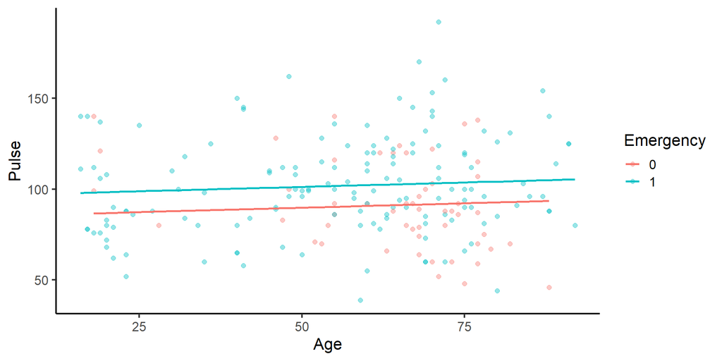

```r
ggplot(data = ICU_aug,
       aes(x = Age, y = Pulse,
           group = Emergency)) +
  geom_point(aes(color = as.factor(Emergency)),
             alpha = 0.4, size = 2) +
  geom_line(aes(y = .fitted, color = as.factor(Emergency)),
            linewidth = 1) +
  labs(color = "Emergency")
```

## 2.6 Assumptions: Residuals

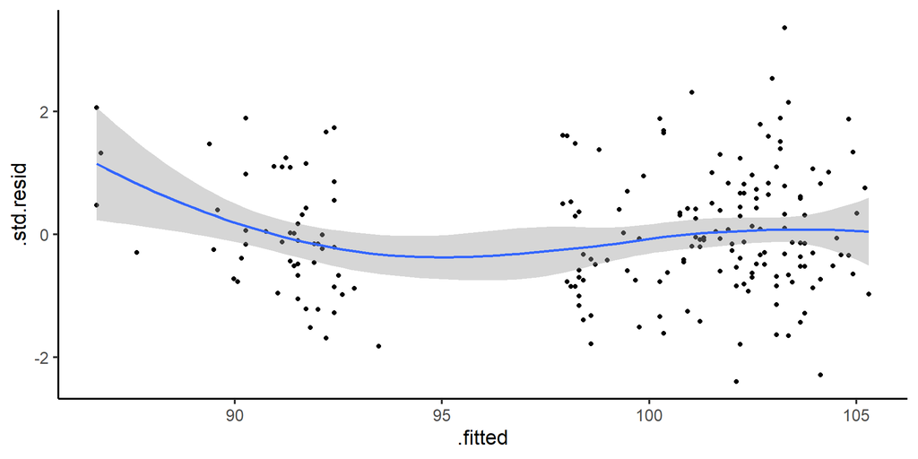

```r
ggplot(data = ICU_aug,
       aes(x = .fitted,
           y = .std.resid)) +
  geom_point() +
  geom_smooth()
```

## 2.7 Assumptions: Residuals

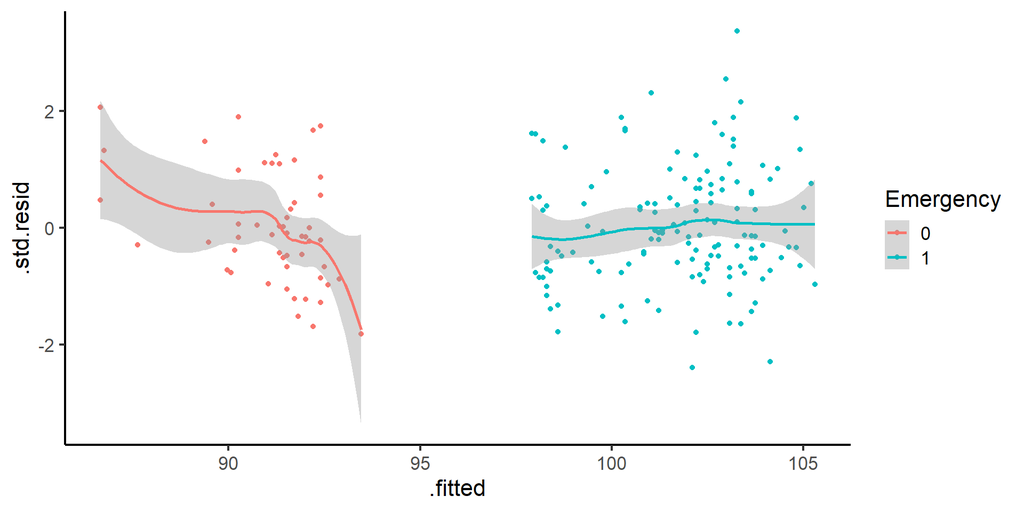

```r
ggplot(data = ICU_aug,
       aes(x = .fitted,
           y = .std.resid,
           color = as.factor(Emergency))) +
  geom_point() +
  geom_smooth() +
  labs(color = "Emergency")
```

## 2.8 More going on?

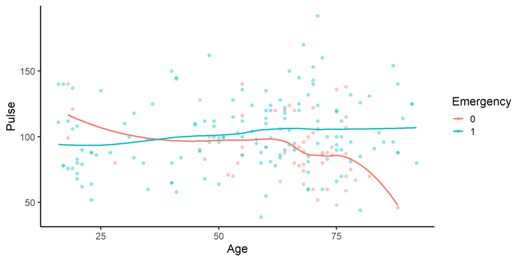

```r
ggplot(data = ICU,
       aes(x = Age,
           y = Pulse,
           group = Emergency)) +
  geom_point(aes(color = as.factor(Emergency)),
             alpha = 0.4,
             size = 2) +
  geom_smooth(se = FALSE,
              aes(color = as.factor(Emergency))) +
  labs(color = "Emergency")
```

## 2.9 More going on?

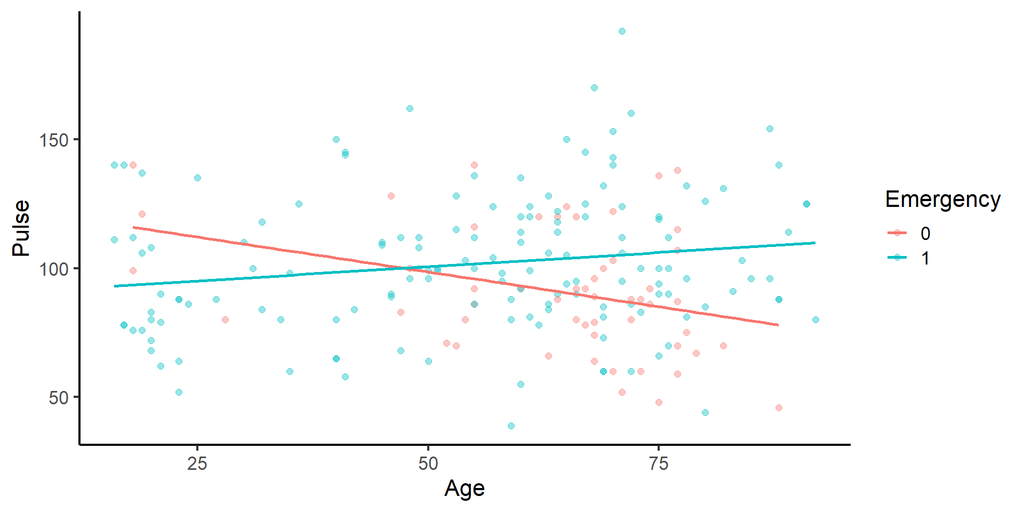

```r
ggplot(data = ICU,
       aes(x = Age,
           y = Pulse,
           group = Emergency)) +
  geom_point(aes(color = as.factor(Emergency)),
             alpha = 0.4,
             size = 2) +
  geom_smooth(method = "lm",
              se = FALSE,
              aes(color = as.factor(Emergency))) +
  labs(color = "Emergency")
```

# 3 Interactions (moderation)

## 3.1 Interaction is a product term

$$\hat{Pulse} = b_0 + b_1 Emergency + b_2 Age + b_3 Emergency\times Age$$

- `Emergency` and `Age` have their own effects
- But they do something special **together**
- The effect of *one predictor* is **conditional on** (or **depends on**) the value of the *other predictor*
- Non-parallel lines

## 3.2 Interaction effect

```r
m2 <- lm(data = ICU, Pulse ~ Emergency + Age + Emergency*Age)
summary(m2)
```

```
Call:
lm(formula = Pulse ~ Emergency + Age + Emergency * Age, data = ICU)

Residuals:
    Min      1Q  Median      3Q     Max
-63.557 -16.917  -3.928  16.011  86.799

Coefficients:
              Estimate Std. Error t value Pr(>|t|)
(Intercept)   125.6093    15.2350   8.245 2.35e-14 ***
Emergency     -36.0513    16.3861  -2.200  0.02897 *
Age            -0.5409     0.2323  -2.329  0.02088 *
Emergency:Age   0.7612     0.2537   3.001  0.00304 **
---
Signif. codes:  0 '***' 0.001 '**' 0.01 '*' 0.05 '.' 0.1 ' ' 1

Residual standard error: 25.96 on 196 degrees of freedom
Multiple R-squared:  0.07817,   Adjusted R-squared:  0.06406
F-statistic:  5.54 on 3 and 196 DF,  p-value: 0.001137
```

## 3.3 Interaction effect

$$\hat{Pulse} = 125.609 + -36.051 Emergency +$$
$$-0.541 Age + 0.761 Emergency\times Age$$

- Simplify for the two `Emergency` groups
  - Substitute 0 and 1 for `Emergency`

## 3.4 Interaction effect

- `Emergency` = 0
  - $\hat{Pulse} = 125.609 + -36.051 (0) + -0.541 Age + 0.761 (0)\times Age$
  - $\hat{Pulse} = 125.609 + -0.541 Age$
- `Emergency` = 1
  - $\hat{Pulse} = 125.609 + -36.051 (1) + -0.541 Age + 0.761 (1)\times Age$
  - $\hat{Pulse} = (125.609 -36.051) + (-0.541 + 0.761) Age$
  - $\hat{Pulse} = 89.558 + 0.22 Age$

## 3.5 What do all the coefficients mean?

$$\hat{Pulse} = 125.609 + -36.051 Emergency +$$
$$-0.541 Age + 0.761 Emergency\times Age$$

- Intercept: 125.609
  - Expected `Pulse` when all predictors are equal to 0
  - `Emergency` = 0 and `Age` = 0
  - `Pulse` for non-emergency admit newborn

## 3.6 What do all the coefficients mean?

$$\hat{Pulse} = 125.609 + -36.051 Emergency +$$
$$-0.541 Age + 0.761 Emergency\times Age$$

- `Emergency` effect = -36.051
  - **Difference** in `Pulse` between emergency and non-emergency admits **when `Age` equals 0**
  - In this case, an *intercept* difference

## 3.7 What do all the coefficients mean?

$$\hat{Pulse} = 125.609 + -36.051 Emergency +$$
$$-0.541 Age + 0.761 Emergency\times Age$$

- `Age` effect = -0.541
  - Expected change in `Pulse` for a 1 unit change in `Age` **when `Emergency` equals 0**
  - *Slope* wrt `Age` for `Emergency` = 0 group

## 3.8 What do all the coefficients mean?

$$\hat{Pulse} = 125.609 + -36.051 Emergency +$$
$$-0.541 Age + 0.761 Emergency\times Age$$

- Interaction = 0.761
  - **Difference** in `Age` slopes between emergency and non admits
  - Significant interaction = **slopes are different**
  - Not parallel lines

## 3.9 Plot of interaction

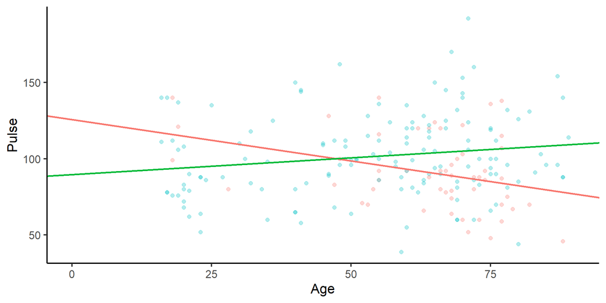

```r
ggplot(data = ICU,
       aes(x = Age,
           y = Pulse,
           group = Emergency)) +
  geom_point(aes(color = as.factor(Emergency)),
             alpha = 0.3,
             size = 2) +
  geom_abline(slope = -0.541,
              intercept = 125.609,
              linewidth = 1,
              color = "#F8766D") +
  geom_abline(slope = 0.22,
              intercept = 89.558,
              linewidth = 1,
              color = "#00BA38") +
  xlim(0, 90) +
  theme(legend.position="none")
```

$\hat{Pulse} = 125.609 + -36.051 Emergency + -0.541 Age + 0.761 Emergency\times Age$

## 3.10 Plot of interaction

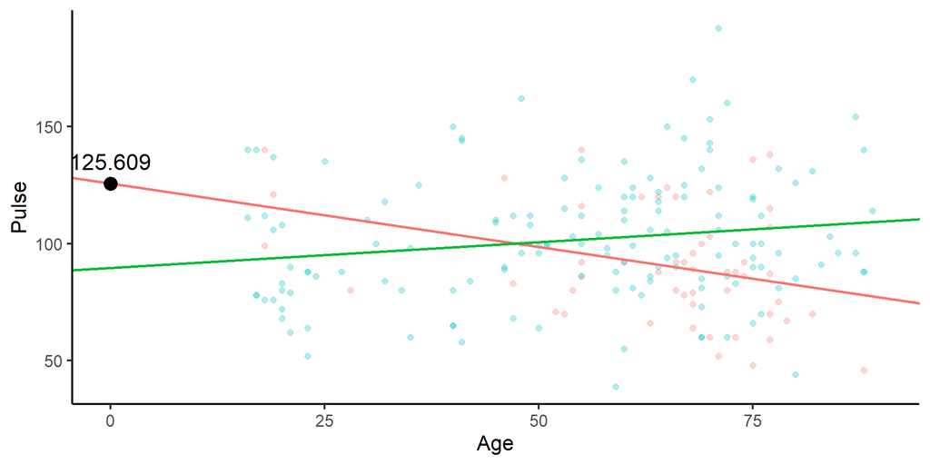

```r
ggplot(data = ICU,
       aes(x = Age,
           y = Pulse,
           group = Emergency)) +
  geom_point(aes(color = as.factor(Emergency)),
             alpha = 0.3,
             size = 2) +
  geom_abline(slope = -0.541,
              intercept = 125.609,
              linewidth = 1,
              color = "#F8766D") +
  geom_abline(slope = 0.22,
              intercept = 89.558,
              linewidth = 1,
              color = "#00BA38") +
  xlim(0, 90) +
  theme(legend.position="none") +
  annotate("pointrange",
           x = 0, y = 125.609,
           ymin = 125.609, ymax = 125.609,
           size = 1) +
  annotate("text", x = 0, y = 135, label = "125.609", size = 6)
```

$\hat{Pulse} = 125.609 + -36.051 Emergency + -0.541 Age + 0.761 Emergency\times Age$

## 3.11 Plot of interaction

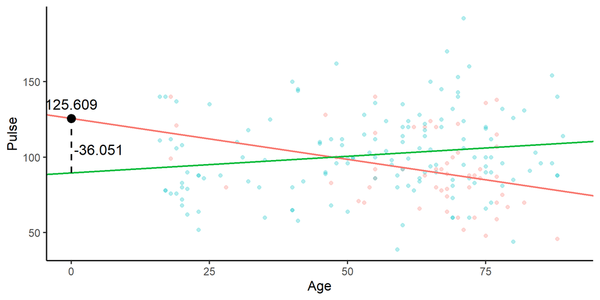

```r
ggplot(data = ICU,
       aes(x = Age,
           y = Pulse,
           group = Emergency)) +
  geom_point(aes(color = as.factor(Emergency)),
             alpha = 0.3,
             size = 2) +
  geom_abline(slope = -0.541,
              intercept = 125.609,
              linewidth = 1,
              color = "#F8766D") +
  geom_abline(slope = 0.22,
              intercept = 89.558,
              linewidth = 1,
              color = "#00BA38") +
  xlim(0, 90) +
  theme(legend.position="none") +
  annotate("pointrange",
           x = 0, y = 125.609,
           ymin = 125.609, ymax = 125.609,
           size = 1) +
  annotate("text", x = 0, y = 135, label = "125.609", size = 6) +
  geom_segment(x = 0, xend = 0,
               y = 89.558, yend = 125.609,
               linewidth = 1, linetype = "dashed") +
  annotate("text", x = 5, y = 105, label = "-36.051", size = 6)
```

$\hat{Pulse} = 125.609 + -36.051 Emergency + -0.541 Age + 0.761 Emergency\times Age$

## 3.12 Plot of interaction

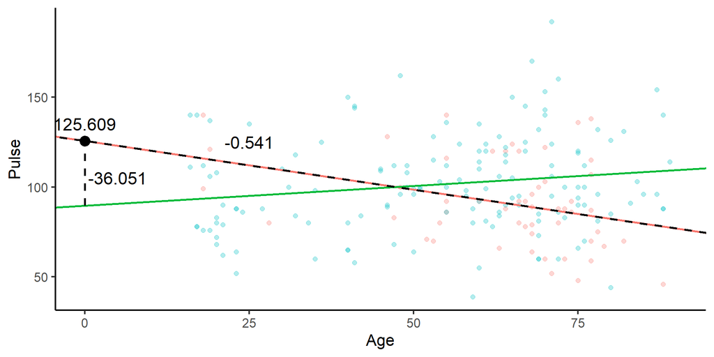

```r
ggplot(data = ICU,
       aes(x = Age,
           y = Pulse,
           group = Emergency)) +
  geom_point(aes(color = as.factor(Emergency)),
             alpha = 0.3,
             size = 2) +
  geom_abline(slope = -0.541,
              intercept = 125.609,
              linewidth = 1,
              color = "#F8766D") +
  geom_abline(slope = 0.22,
              intercept = 89.558,
              linewidth = 1,
              color = "#00BA38") +
  xlim(0, 90) +
  theme(legend.position="none") +
  annotate("pointrange",
           x = 0, y = 125.609,
           ymin = 125.609, ymax = 125.609,
           size = 1) +
  annotate("text", x = 0, y = 135, label = "125.609", size = 6) +
  geom_segment(x = 0, xend = 0,
               y = 89.558, yend = 125.609,
               linewidth = 1, linetype = "dashed") +
  annotate("text", x = 5, y = 105, label = "-36.051", size = 6) +
  geom_abline(intercept = 125.609, slope = -0.541,
              linetype = "dashed", linewidth = 1) +
  annotate("text", x = 25, y = 125, label = "-0.541", size = 6)
```

$\hat{Pulse} = 125.609 + -36.051 Emergency + -0.541 Age + 0.761 Emergency\times Age$

## 3.13 Plot of interaction

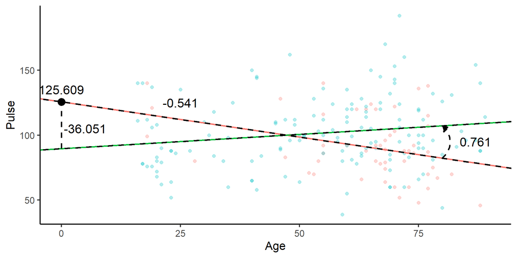

```r
ggplot(data = ICU,
       aes(x = Age,
           y = Pulse,
           group = Emergency)) +
  geom_point(aes(color = as.factor(Emergency)),
             alpha = 0.3,
             size = 2) +
  geom_abline(slope = -0.541,
              intercept = 125.609,
              linewidth = 1,
              color = "#F8766D") +
  geom_abline(slope = 0.22,
              intercept = 89.558,
              linewidth = 1,
              color = "#00BA38") +
  xlim(0, 90) +
  theme(legend.position="none") +
  annotate("pointrange",
           x = 0, y = 125.609,
           ymin = 125.609, ymax = 125.609,
           size = 1) +
  annotate("text", x = 0, y = 135, label = "125.609", size = 6) +
  geom_segment(x = 0, xend = 0,
               y = 89.558, yend = 125.609,
               linewidth = 1, linetype = "dashed") +
  annotate("text", x = 5, y = 105, label = "-36.051", size = 6) +
  geom_abline(intercept = 125.609, slope = -0.541,
              linetype = "dashed", linewidth = 1) +
  annotate("text", x = 25, y = 125, label = "-0.541", size = 6) +
  geom_abline(intercept = 89.558, slope = 0.22,
              linetype = "dashed", linewidth = 1) +
  geom_curve(x = 80, xend = 80,
             y = 82.329, yend = 107.158,
             linewidth = 1, linetype = "dashed",
             arrow = arrow(length = unit(0.3, "cm"),
                           type = "closed")) +
  annotate("text", x = 87, y = 95, label = "0.761", size = 6)
```

$\hat{Pulse} = 125.609 + -36.051 Emergency + -0.541 Age + 0.761 Emergency\times Age$

## 3.14 Center continuous predictors

- Recommended to **mean center** continuous predictors
  - Interpretable intercept
  - Interpretable lower order effects
  - Reduces collinearity between interaction and other predictors
- Use centered predictor in all places in the model

## 3.15 Center continuous predictors

```r
ICU <- ICU %>% mutate(AgeC = Age - mean(Age, na.rm = TRUE))
m3 <- lm(data = ICU, Pulse ~ Emergency + AgeC + Emergency*AgeC)
summary(m3)
```

```
Call:
lm(formula = Pulse ~ Emergency + AgeC + Emergency * AgeC, data = ICU)

Residuals:
    Min      1Q  Median      3Q     Max
-63.557 -16.917  -3.928  16.011  86.799

Coefficients:
               Estimate Std. Error t value Pr(>|t|)
(Intercept)     94.4823     3.8476  24.556  < 2e-16 ***
Emergency        7.7539     4.4091   1.759  0.08020 .
AgeC            -0.5409     0.2323  -2.329  0.02088 *
Emergency:AgeC   0.7612     0.2537   3.001  0.00304 **
---
Signif. codes:  0 '***' 0.001 '**' 0.01 '*' 0.05 '.' 0.1 ' ' 1

Residual standard error: 25.96 on 196 degrees of freedom
Multiple R-squared:  0.07817,   Adjusted R-squared:  0.06406
F-statistic:  5.54 on 3 and 196 DF,  p-value: 0.001137
```

## 3.16 What changes?

- Lower order terms because **“…when `Age` = 0”**
  - Intercept: 125.609 $\rightarrow$ 94.482
    - Now at mean of `Age` instead of `Age` = 0
  - Effect of `Emergency`: -36.051 $\rightarrow$ 7.754
    - Now at mean of `Age` instead of `Age` = 0
- Collinearity
  - Standard errors are **reduced** with centering for some terms

## 3.17 Collinearity before and after centering

```r
library(car)
vif(m2)
```

```
    Emergency           Age Emergency:Age
    15.525294      6.408342     17.562327
```

```r
vif(m3)
```

```
     Emergency           AgeC Emergency:AgeC
      1.124039       6.408342       6.203115
```

- Though don’t worry about this **too** much, esp for product term
  - https://statisticalhorizons.com/multicollinearity/
  - https://search.r-project.org/CRAN/refmans/car/html/vif.html

## 3.18 What doesn’t change?

- Higher order terms
  - Interaction: 0.761
  - Effect of `Age` (slope): -0.541
- $R^2_{multiple}$ and associated tests
- Log-likelihood

## 3.19 Uncentered `Age`

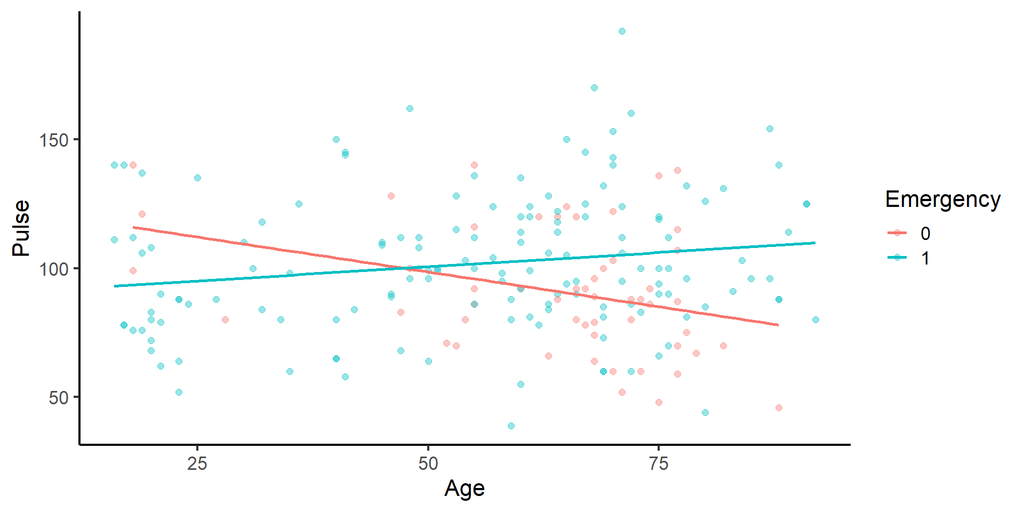

```r
ggplot(data = ICU,
       aes(x = Age,
           y = Pulse,
           group = Emergency)) +
  geom_point(aes(color = as.factor(Emergency)),
             alpha = 0.4,
             size = 2) +
  geom_smooth(method = "lm",
              se = FALSE,
              aes(color = as.factor(Emergency))) +
  labs(color = "Emergency")
```

## 3.20 Centered `Age`

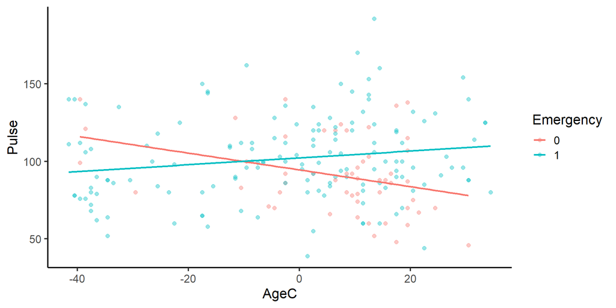

```r
ggplot(data = ICU,
       aes(x = AgeC,
           y = Pulse,
           group = Emergency)) +
  geom_point(aes(color = as.factor(Emergency)),
             alpha = 0.4,
             size = 2) +
  geom_smooth(method = "lm",
              se = FALSE,
              aes(color = as.factor(Emergency))) +
  labs(color = "Emergency")
```

## 3.21 Probing the interaction

- **Simple slopes**: Slopes at specific values
  - `Emergency` = 0: $\hat{Pulse} = 125.609 + -0.541 Age$
  - `Emergency` = 1: $\hat{Pulse} = 89.558 + 0.22 Age$
- We know (from the original analysis)
  - Significance of coefficients for “group = 0”
  - Significance of **differences** between the groups
- **What about “group = 1”?**

## 3.22 Two approaches

- **Method 1**: *Recode your group variable* from 0,1 to 1,0
  - Now the group that **was** 1 is now 0
  - Interpret the intercept and slope for that group
- **Method 2**: *Calculate things*
  - Uses the variances and covariance of coefficients (`vcov()`)
  - See Aiken & West (1991), Preacher, Curran, Bauer (2006)

## 3.23 Packages to make this easier for you

- Non-exhaustive list of packages
- **interactions**: https://cran.r-project.org/package=interactions
- **marginaleffects**: https://cran.r-project.org/package=marginaleffects
  - Also https://marginaleffects.com/
- **sjPlot**: https://cran.r-project.org/package=sjPlot

## 3.24 Plot simple slopes

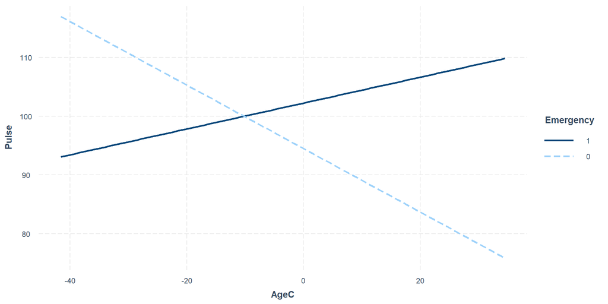

```r
library(interactions)
interact_plot(m3,
              pred = AgeC,
              modx = Emergency)
```

## 3.25 Plot simple slopes with data

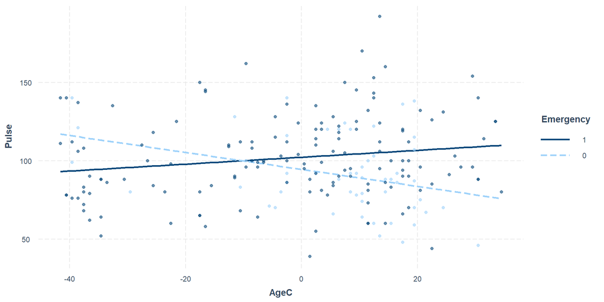

```r
interact_plot(m3,
              pred = AgeC,
              modx = Emergency,
              plot.points = TRUE)
```

## 3.26 Simple slopes analysis

```r
sim_slopes(m3,
           pred = AgeC,
           modx = Emergency,
           johnson_neyman = FALSE)
```

```
SIMPLE SLOPES ANALYSIS

Slope of AgeC when Emergency = 0.00 (0):

   Est.   S.E.   t val.      p
------- ------ -------- ------
  -0.54   0.23    -2.33   0.02

Slope of AgeC when Emergency = 1.00 (1):

  Est.   S.E.   t val.      p
------ ------ -------- ------
  0.22   0.10     2.16   0.03
```

## 3.27 Johnson-Neyman intervals

- For **which values of `AgeC`** are the `Emergency` groups **different**?
  - Not about the **slopes** but about the **values**
- Johnson, P. O., & Fay, L. C. (1950). The Johnson-Neyman technique, its theory and application. *Psychometrika*, 15, 349–367.

## 3.28 Johnson-Neyman intervals

```r
sim_slopes(m3,
           pred = AgeC,
           modx = Emergency,
           johnson_neyman = TRUE)
```

```
JOHNSON-NEYMAN INTERVAL

When Emergency is OUTSIDE the interval [0.26, 0.97], the slope of AgeC is p
< .05.

Note: The range of observed values of Emergency is [0.00, 1.00]

SIMPLE SLOPES ANALYSIS

Slope of AgeC when Emergency = 0.00 (0):

   Est.   S.E.   t val.      p
------- ------ -------- ------
  -0.54   0.23    -2.33   0.02

Slope of AgeC when Emergency = 1.00 (1):

  Est.   S.E.   t val.      p
------ ------ -------- ------
  0.22   0.10     2.16   0.03
```

## 3.29 Johnson-Neyman intervals: Improved

```r
sim_slopes(m3,
           pred = Emergency,
           modx = AgeC,
           johnson_neyman = TRUE)
```

```
JOHNSON-NEYMAN INTERVAL

When AgeC is OUTSIDE the interval [-44.31, 1.06], the slope of Emergency is
p < .05.

Note: The range of observed values of AgeC is [-41.55, 34.45]

SIMPLE SLOPES ANALYSIS

Slope of Emergency when AgeC = -2.005465e+01 (- 1 SD):

   Est.   S.E.   t val.      p
------- ------ -------- ------
  -7.51   7.61    -0.99   0.32

Slope of Emergency when AgeC = -1.705303e-15 (Mean):

  Est.   S.E.   t val.      p
------ ------ -------- ------
  7.75   4.41     1.76   0.08

Slope of Emergency when AgeC =  2.005465e+01 (+ 1 SD):

   Est.   S.E.   t val.      p
------- ------ -------- ------
  23.02   5.73     4.02   0.00
```

## 3.30 Johnson-Neyman intervals: Plot

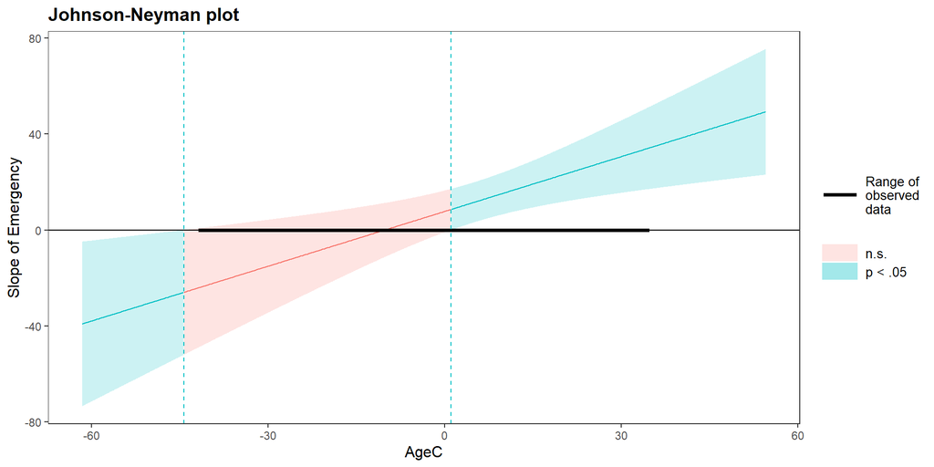

```
JOHNSON-NEYMAN INTERVAL

When AgeC is OUTSIDE the interval [-44.31, 1.06], the slope of Emergency is
p < .05.

Note: The range of observed values of AgeC is [-41.55, 34.45]
```

```r
johnson_neyman(m3,
               pred = Emergency,
               modx = AgeC,
               alpha = .05)
```

# 4 Miscellaneous

## 4.1 Main effects vs simple effects

- Factorial ANOVA: **Main effects** + interaction
  - **Main effect**: Effect of a predictor **averaged across** the levels of the other predictors
  - *Overall effect*
- Linear regression: **Simple (main) effects** + interaction
  - **Simple effect**: Effect of a predictor **at a specific value** of the other predictors
  - *Conditional effect*

## 4.2 Main effects vs simple effects

- In general: Don’t use the term “main effects” for regression
  - “Simple slopes” for the actual simple slopes
  - “Lower order effects” for the coefficients (i.e., $b_1$ and $b_2$)
- If interaction is significant
  - Lower order effects are conditional, so make sure to talk about them accordingly

## 4.3 Two continuous predictors

```r
ICU <- ICU %>% mutate(SysBPC = SysBP - mean(SysBP, na.rm = TRUE))
m4 <- lm(data = ICU, Pulse ~ AgeC + SysBPC + AgeC*SysBPC)
summary(m4)
```

```
Call:
lm(formula = Pulse ~ AgeC + SysBPC + AgeC * SysBPC, data = ICU)

Residuals:
    Min      1Q  Median      3Q     Max
-63.441 -18.022  -3.145  19.010  93.346

Coefficients:
             Estimate Std. Error t value Pr(>|t|)
(Intercept) 98.977148   1.908781  51.854   <2e-16 ***
AgeC         0.049134   0.095734   0.513    0.608
SysBPC      -0.037546   0.061418  -0.611    0.542
AgeC:SysBPC -0.001862   0.003779  -0.493    0.623
---
Signif. codes:  0 '***' 0.001 '**' 0.01 '*' 0.05 '.' 0.1 ' ' 1

Residual standard error: 26.95 on 196 degrees of freedom
Multiple R-squared:  0.006018,  Adjusted R-squared:  -0.009196
F-statistic: 0.3955 on 3 and 196 DF,  p-value: 0.7563
```

## 4.4 Simple slopes

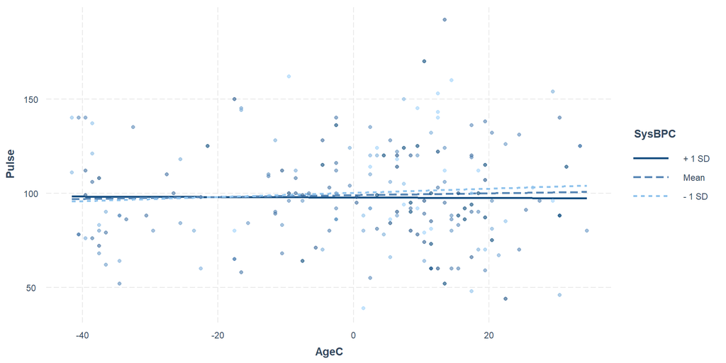

```r
interact_plot(m4,
              pred = AgeC,
              modx = SysBPC,
              plot.points = TRUE)
```

# 5 Next time

## 5.1 Non-normal outcomes

- Logistic regression for **binary** outcomes
- Poisson regressoin for **count** outcomes
- Survival analysis for **survival** outcomes